# FACTORS THAT INFLUENCE THE LENGTH OF GOBIKE TRIPS

## by Johnpaul Kosisochukwu Nwagwu

## Investigation Overview

> In this Investigation I was to investigation factors that affect the length of a trip duration. The main focus was on the trip days, user types, trip hours and if trip was shared or not.

## Dataset Overview

> The Ford GoBike Dataset contains approximately 183,000 entries of individual rides made in a bike sharing system in Greater SanFrancisco Bay area in February 2019. The data set can be found here https://video.udacity-data.com/topher/2020/October/5f91cf38_201902-fordgobike-tripdata/201902-fordgobike-tripdata.csv. We will explore important features such as duration_sec, start_hour, end_hour, member_gender, user_type and start_dayname among others. Some of these features were extracted from existing variables. Data Wrangling performed include Change start time to date time type and split to day, dayname, month and year columns and Change end time to date time type and split to day, dayname, month and year columns

## DISTRIBUTION OF TRIP LENGTHS

> The distribution of the trip duration is right skewed with most trips lasting between about 300 to 700 seconds. There also appears to trip lengths are big as 80,000 seconds

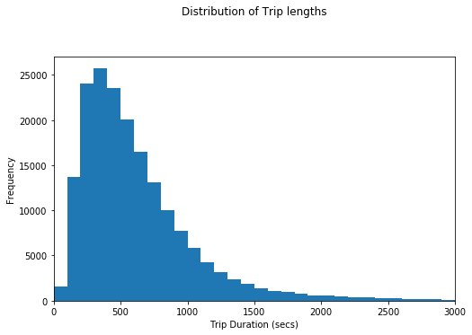

## DISTRIBUTION OF TRIPS BY DAYS

> Most trips were made on thursdays with over 35000 trips with the least trip of about 15,000 made on weekends(Saturdays and Sundays)

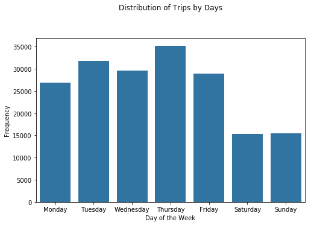

## DISTRIBUTION OF TRIPS BY USER TYPES

> More than 80% of users in our data are subscribers. We have over 160,000 susbcribers abnd about 20,000 customers

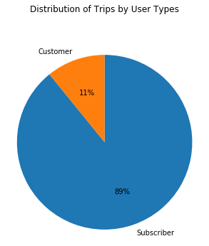

## DISTRIBUTION OF TRIP HOURS

> We see that the top 5 Most travelled hours are 17:00, 8:00, 18:00, 9:00 and 16:00. These are work trip times. Also, the least trips are taken in the early hours of the morning and midnight.

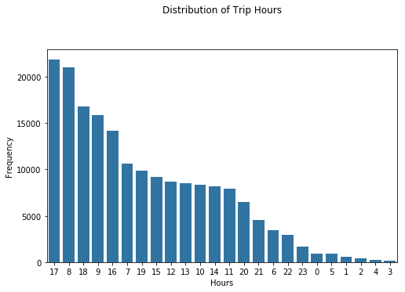

## DISTRIBUTION OF TRIP TYPES

> We can see that about 90% of trips were individual trips(not shared)

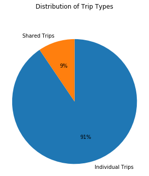

## BIKE SHARE FOR ALL TRIPS VS USER TYPES

> We can see that all shared trips are by Suscribers only. No customer shared a trip

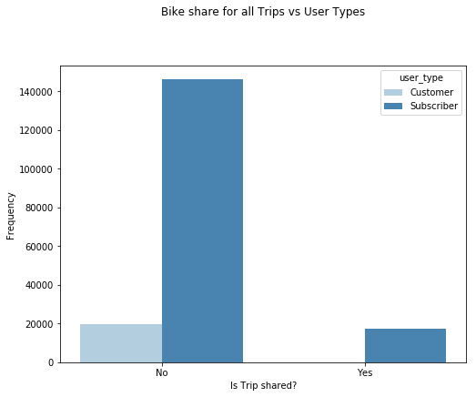

> So in general for hours between 4:00 and 21:00, The Customers spend more time travelling than the subscribers with the peak travel time being between 11:00 and 15:00 and less than 1100 seconds. The Suscribers peak travel duration is almost constant at about 600 seconds

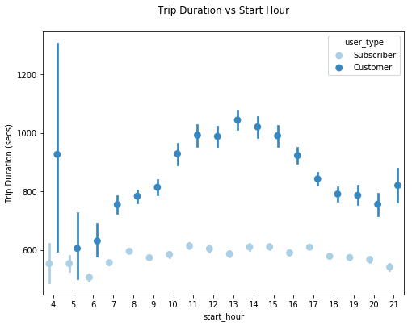

## THE END. HAVE A GREAT DAY